# Risk Factor Analysis

## Outcome Variable

**Outcome Variable:** wasted

## Predictor Variables

**Intervention Variable:** cleanck

**Adjustment Set:**

unadjusted

## Stratifying Variables

The analysis was stratified on these variable(s):

- agecat
- studyid
- country

## Data Summary

| agecat | studyid | country | cleanck | wasted | n_cell | n | outcome_variable |
| --- | --- | --- | --- | --- | --- | --- | --- |
| Birth | ki0047075b-MAL-ED | PERU | 1 | 0 | 1 | 2 | wasted |
| Birth | ki0047075b-MAL-ED | PERU | 1 | 1 | 0 | 2 | wasted |
| Birth | ki0047075b-MAL-ED | PERU | 0 | 0 | 1 | 2 | wasted |
| Birth | ki0047075b-MAL-ED | PERU | 0 | 1 | 0 | 2 | wasted |
| Birth | ki1000108-CMC-V-BCS-2002 | INDIA | 1 | 0 | 34 | 86 | wasted |
| Birth | ki1000108-CMC-V-BCS-2002 | INDIA | 1 | 1 | 3 | 86 | wasted |
| Birth | ki1000108-CMC-V-BCS-2002 | INDIA | 0 | 0 | 41 | 86 | wasted |
| Birth | ki1000108-CMC-V-BCS-2002 | INDIA | 0 | 1 | 8 | 86 | wasted |
| Birth | ki1000108-IRC | INDIA | 1 | 0 | 157 | 337 | wasted |
| Birth | ki1000108-IRC | INDIA | 1 | 1 | 41 | 337 | wasted |
| Birth | ki1000108-IRC | INDIA | 0 | 0 | 91 | 337 | wasted |
| Birth | ki1000108-IRC | INDIA | 0 | 1 | 48 | 337 | wasted |
| Birth | ki1017093b-PROVIDE | BANGLADESH | 1 | 0 | 341 | 532 | wasted |
| Birth | ki1017093b-PROVIDE | BANGLADESH | 1 | 1 | 92 | 532 | wasted |
| Birth | ki1017093b-PROVIDE | BANGLADESH | 0 | 0 | 74 | 532 | wasted |
| Birth | ki1017093b-PROVIDE | BANGLADESH | 0 | 1 | 25 | 532 | wasted |
| Birth | ki1017093c-NIH-Crypto | BANGLADESH | 1 | 0 | 275 | 543 | wasted |
| Birth | ki1017093c-NIH-Crypto | BANGLADESH | 1 | 1 | 61 | 543 | wasted |
| Birth | ki1017093c-NIH-Crypto | BANGLADESH | 0 | 0 | 146 | 543 | wasted |
| Birth | ki1017093c-NIH-Crypto | BANGLADESH | 0 | 1 | 61 | 543 | wasted |
| Birth | ki1113344-GMS-Nepal | NEPAL | 1 | 0 | 5 | 570 | wasted |
| Birth | ki1113344-GMS-Nepal | NEPAL | 1 | 1 | 4 | 570 | wasted |
| Birth | ki1113344-GMS-Nepal | NEPAL | 0 | 0 | 448 | 570 | wasted |
| Birth | ki1113344-GMS-Nepal | NEPAL | 0 | 1 | 113 | 570 | wasted |
| 6 months | ki0047075b-MAL-ED | SOUTH AFRICA | 1 | 0 | 1 | 1 | wasted |
| 6 months | ki0047075b-MAL-ED | SOUTH AFRICA | 1 | 1 | 0 | 1 | wasted |
| 6 months | ki0047075b-MAL-ED | SOUTH AFRICA | 0 | 0 | 0 | 1 | wasted |
| 6 months | ki0047075b-MAL-ED | SOUTH AFRICA | 0 | 1 | 0 | 1 | wasted |
| 6 months | ki1000108-CMC-V-BCS-2002 | INDIA | 1 | 0 | 146 | 368 | wasted |
| 6 months | ki1000108-CMC-V-BCS-2002 | INDIA | 1 | 1 | 16 | 368 | wasted |
| 6 months | ki1000108-CMC-V-BCS-2002 | INDIA | 0 | 0 | 176 | 368 | wasted |
| 6 months | ki1000108-CMC-V-BCS-2002 | INDIA | 0 | 1 | 30 | 368 | wasted |
| 6 months | ki1000108-IRC | INDIA | 1 | 0 | 195 | 398 | wasted |
| 6 months | ki1000108-IRC | INDIA | 1 | 1 | 34 | 398 | wasted |
| 6 months | ki1000108-IRC | INDIA | 0 | 0 | 150 | 398 | wasted |
| 6 months | ki1000108-IRC | INDIA | 0 | 1 | 19 | 398 | wasted |
| 6 months | ki1017093b-PROVIDE | BANGLADESH | 1 | 0 | 481 | 603 | wasted |
| 6 months | ki1017093b-PROVIDE | BANGLADESH | 1 | 1 | 16 | 603 | wasted |
| 6 months | ki1017093b-PROVIDE | BANGLADESH | 0 | 0 | 97 | 603 | wasted |
| 6 months | ki1017093b-PROVIDE | BANGLADESH | 0 | 1 | 9 | 603 | wasted |
| 6 months | ki1017093c-NIH-Crypto | BANGLADESH | 1 | 0 | 321 | 545 | wasted |
| 6 months | ki1017093c-NIH-Crypto | BANGLADESH | 1 | 1 | 8 | 545 | wasted |
| 6 months | ki1017093c-NIH-Crypto | BANGLADESH | 0 | 0 | 211 | 545 | wasted |
| 6 months | ki1017093c-NIH-Crypto | BANGLADESH | 0 | 1 | 5 | 545 | wasted |
| 6 months | ki1113344-GMS-Nepal | NEPAL | 1 | 0 | 8 | 505 | wasted |
| 6 months | ki1113344-GMS-Nepal | NEPAL | 1 | 1 | 0 | 505 | wasted |
| 6 months | ki1113344-GMS-Nepal | NEPAL | 0 | 0 | 451 | 505 | wasted |
| 6 months | ki1113344-GMS-Nepal | NEPAL | 0 | 1 | 46 | 505 | wasted |
| 24 months | ki0047075b-MAL-ED | SOUTH AFRICA | 1 | 0 | 1 | 1 | wasted |
| 24 months | ki0047075b-MAL-ED | SOUTH AFRICA | 1 | 1 | 0 | 1 | wasted |
| 24 months | ki0047075b-MAL-ED | SOUTH AFRICA | 0 | 0 | 0 | 1 | wasted |
| 24 months | ki0047075b-MAL-ED | SOUTH AFRICA | 0 | 1 | 0 | 1 | wasted |
| 24 months | ki1000108-CMC-V-BCS-2002 | INDIA | 1 | 0 | 157 | 372 | wasted |
| 24 months | ki1000108-CMC-V-BCS-2002 | INDIA | 1 | 1 | 6 | 372 | wasted |
| 24 months | ki1000108-CMC-V-BCS-2002 | INDIA | 0 | 0 | 192 | 372 | wasted |
| 24 months | ki1000108-CMC-V-BCS-2002 | INDIA | 0 | 1 | 17 | 372 | wasted |
| 24 months | ki1000108-IRC | INDIA | 1 | 0 | 216 | 400 | wasted |
| 24 months | ki1000108-IRC | INDIA | 1 | 1 | 15 | 400 | wasted |
| 24 months | ki1000108-IRC | INDIA | 0 | 0 | 153 | 400 | wasted |
| 24 months | ki1000108-IRC | INDIA | 0 | 1 | 16 | 400 | wasted |
| 24 months | ki1017093b-PROVIDE | BANGLADESH | 1 | 0 | 438 | 579 | wasted |
| 24 months | ki1017093b-PROVIDE | BANGLADESH | 1 | 1 | 42 | 579 | wasted |
| 24 months | ki1017093b-PROVIDE | BANGLADESH | 0 | 0 | 79 | 579 | wasted |
| 24 months | ki1017093b-PROVIDE | BANGLADESH | 0 | 1 | 20 | 579 | wasted |
| 24 months | ki1017093c-NIH-Crypto | BANGLADESH | 1 | 0 | 185 | 410 | wasted |
| 24 months | ki1017093c-NIH-Crypto | BANGLADESH | 1 | 1 | 14 | 410 | wasted |
| 24 months | ki1017093c-NIH-Crypto | BANGLADESH | 0 | 0 | 193 | 410 | wasted |
| 24 months | ki1017093c-NIH-Crypto | BANGLADESH | 0 | 1 | 18 | 410 | wasted |
| 24 months | ki1113344-GMS-Nepal | NEPAL | 1 | 0 | 4 | 434 | wasted |
| 24 months | ki1113344-GMS-Nepal | NEPAL | 1 | 1 | 1 | 434 | wasted |
| 24 months | ki1113344-GMS-Nepal | NEPAL | 0 | 0 | 350 | 434 | wasted |
| 24 months | ki1113344-GMS-Nepal | NEPAL | 0 | 1 | 79 | 434 | wasted |

The following strata were considered:

- agecat: 24 months, studyid: ki0047075b-MAL-ED, country: SOUTH AFRICA
- agecat: 24 months, studyid: ki1000108-CMC-V-BCS-2002, country: INDIA
- agecat: 24 months, studyid: ki1000108-IRC, country: INDIA
- agecat: 24 months, studyid: ki1017093b-PROVIDE, country: BANGLADESH
- agecat: 24 months, studyid: ki1017093c-NIH-Crypto, country: BANGLADESH
- agecat: 24 months, studyid: ki1113344-GMS-Nepal, country: NEPAL
- agecat: 6 months, studyid: ki0047075b-MAL-ED, country: SOUTH AFRICA
- agecat: 6 months, studyid: ki1000108-CMC-V-BCS-2002, country: INDIA
- agecat: 6 months, studyid: ki1000108-IRC, country: INDIA
- agecat: 6 months, studyid: ki1017093b-PROVIDE, country: BANGLADESH
- agecat: 6 months, studyid: ki1017093c-NIH-Crypto, country: BANGLADESH
- agecat: 6 months, studyid: ki1113344-GMS-Nepal, country: NEPAL
- agecat: Birth, studyid: ki0047075b-MAL-ED, country: PERU
- agecat: Birth, studyid: ki1000108-CMC-V-BCS-2002, country: INDIA
- agecat: Birth, studyid: ki1000108-IRC, country: INDIA
- agecat: Birth, studyid: ki1017093b-PROVIDE, country: BANGLADESH
- agecat: Birth, studyid: ki1017093c-NIH-Crypto, country: BANGLADESH
- agecat: Birth, studyid: ki1113344-GMS-Nepal, country: NEPAL

### Dropped Strata

Some strata were dropped due to rare outcomes:

- agecat: Birth, studyid: ki0047075b-MAL-ED, country: PERU
- agecat: Birth, studyid: ki1000108-CMC-V-BCS-2002, country: INDIA
- agecat: Birth, studyid: ki1113344-GMS-Nepal, country: NEPAL
- agecat: 6 months, studyid: ki0047075b-MAL-ED, country: SOUTH AFRICA
- agecat: 6 months, studyid: ki1113344-GMS-Nepal, country: NEPAL
- agecat: 24 months, studyid: ki0047075b-MAL-ED, country: SOUTH AFRICA
- agecat: 24 months, studyid: ki1113344-GMS-Nepal, country: NEPAL

## Methods Detail

We’re interested in the causal parameters $E[Y_a]$ for all values of $a \in \mathcal{A}$. These parameters represent the mean outcome if, possibly contrary to fact, we intervened to set all units to have $A=a$. Under the randomization and positivity assumptions, these are identified by the statistical parameters $\psi_a=E_W[E_{Y|A,W}(Y|A=a,W)]$. In addition, we’re interested in the mean of $Y$, $E[Y]$ under no intervention (the observed mean). We will estimate these parameters by using SuperLearner to fit the relevant likelihood factors – $E_{Y|A,W}(Y|A=a,W)$ and $p(A=a|W)$, and then updating our likelihood fit using a joint TMLE.

For unadjusted analyses ($W=\{\}$), initial likelihoods were estimated using Lrnr_glm to estimate the simple $E(Y|A)$ and Lrnr_mean to estimate $p(A)$. For adjusted analyses, a small library containing Lrnr_glmnet, Lrnr_xgboost, and Lrnr_mean was used.

Having estimated these parameters, we will then use the delta method to estimate relative risks and attributable risks relative to a prespecified baseline level of $A$.

# Results Detail

## Results Plots

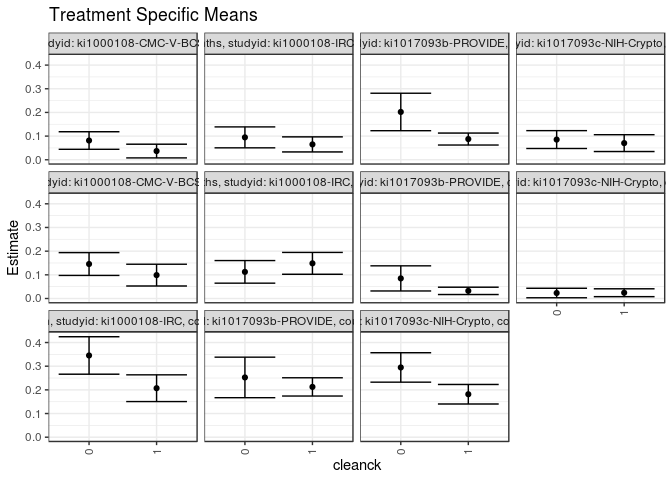

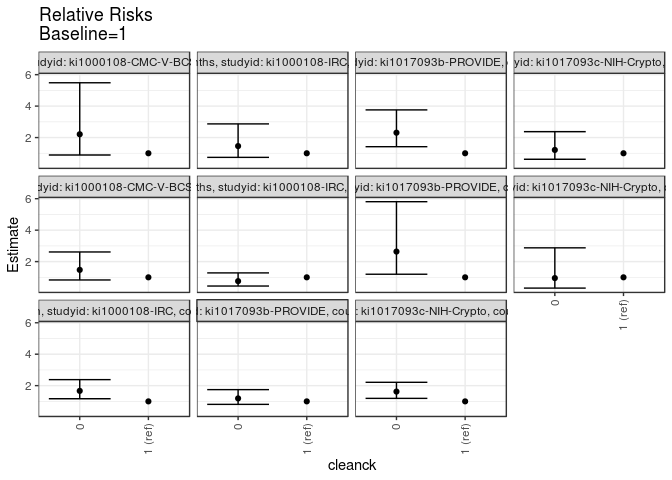

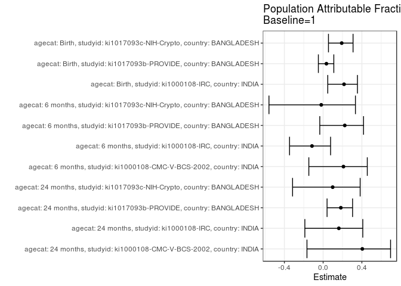

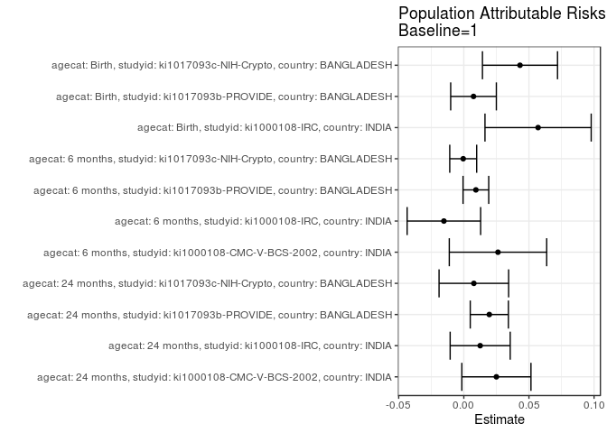

## Results Table

### Parameter: TSM

| agecat | studyid | country | intervention_level | baseline_level | estimate | ci_lower | ci_upper |
| --- | --- | --- | --- | --- | --- | --- | --- |
| Birth | ki1000108-IRC | INDIA | 1 | NA | 0.2070707 | 0.1505461 | 0.2635953 |
| Birth | ki1000108-IRC | INDIA | 0 | NA | 0.3453237 | 0.2661625 | 0.4244850 |
| Birth | ki1017093b-PROVIDE | BANGLADESH | 1 | NA | 0.2124711 | 0.1739059 | 0.2510364 |
| Birth | ki1017093b-PROVIDE | BANGLADESH | 0 | NA | 0.2525253 | 0.1668630 | 0.3381876 |
| Birth | ki1017093c-NIH-Crypto | BANGLADESH | 1 | NA | 0.1815476 | 0.1402932 | 0.2228021 |
| Birth | ki1017093c-NIH-Crypto | BANGLADESH | 0 | NA | 0.2946860 | 0.2325227 | 0.3568493 |
| 6 months | ki1000108-CMC-V-BCS-2002 | INDIA | 1 | NA | 0.0987654 | 0.0527607 | 0.1447702 |
| 6 months | ki1000108-CMC-V-BCS-2002 | INDIA | 0 | NA | 0.1456311 | 0.0973969 | 0.1938653 |
| 6 months | ki1000108-IRC | INDIA | 1 | NA | 0.1484716 | 0.1023613 | 0.1945819 |
| 6 months | ki1000108-IRC | INDIA | 0 | NA | 0.1124260 | 0.0647405 | 0.1601116 |
| 6 months | ki1017093b-PROVIDE | BANGLADESH | 1 | NA | 0.0321932 | 0.0166619 | 0.0477244 |
| 6 months | ki1017093b-PROVIDE | BANGLADESH | 0 | NA | 0.0849057 | 0.0317980 | 0.1380133 |
| 6 months | ki1017093c-NIH-Crypto | BANGLADESH | 1 | NA | 0.0243161 | 0.0076570 | 0.0409752 |
| 6 months | ki1017093c-NIH-Crypto | BANGLADESH | 0 | NA | 0.0231481 | 0.0030761 | 0.0432202 |
| 24 months | ki1000108-CMC-V-BCS-2002 | INDIA | 1 | NA | 0.0368098 | 0.0078646 | 0.0657550 |
| 24 months | ki1000108-CMC-V-BCS-2002 | INDIA | 0 | NA | 0.0813397 | 0.0442299 | 0.1184495 |
| 24 months | ki1000108-IRC | INDIA | 1 | NA | 0.0649351 | 0.0331190 | 0.0967511 |
| 24 months | ki1000108-IRC | INDIA | 0 | NA | 0.0946746 | 0.0504802 | 0.1388690 |
| 24 months | ki1017093b-PROVIDE | BANGLADESH | 1 | NA | 0.0875000 | 0.0621998 | 0.1128002 |
| 24 months | ki1017093b-PROVIDE | BANGLADESH | 0 | NA | 0.2020202 | 0.1228614 | 0.2811790 |
| 24 months | ki1017093c-NIH-Crypto | BANGLADESH | 1 | NA | 0.0703518 | 0.0347765 | 0.1059271 |
| 24 months | ki1017093c-NIH-Crypto | BANGLADESH | 0 | NA | 0.0853081 | 0.0475709 | 0.1230452 |

### Parameter: E(Y)

| agecat | studyid | country | intervention_level | baseline_level | estimate | ci_lower | ci_upper |
| --- | --- | --- | --- | --- | --- | --- | --- |
| Birth | ki1000108-IRC | INDIA | NA | NA | 0.2640950 | 0.2169571 | 0.3112328 |
| Birth | ki1017093b-PROVIDE | BANGLADESH | NA | NA | 0.2199248 | 0.1846953 | 0.2551543 |
| Birth | ki1017093c-NIH-Crypto | BANGLADESH | NA | NA | 0.2246777 | 0.1895403 | 0.2598151 |
| 6 months | ki1000108-CMC-V-BCS-2002 | INDIA | NA | NA | 0.1250000 | 0.0911644 | 0.1588356 |
| 6 months | ki1000108-IRC | INDIA | NA | NA | 0.1331658 | 0.0997450 | 0.1665867 |
| 6 months | ki1017093b-PROVIDE | BANGLADESH | NA | NA | 0.0414594 | 0.0255348 | 0.0573839 |
| 6 months | ki1017093c-NIH-Crypto | BANGLADESH | NA | NA | 0.0238532 | 0.0110305 | 0.0366759 |
| 24 months | ki1000108-CMC-V-BCS-2002 | INDIA | NA | NA | 0.0618280 | 0.0373207 | 0.0863352 |
| 24 months | ki1000108-IRC | INDIA | NA | NA | 0.0775000 | 0.0512641 | 0.1037359 |
| 24 months | ki1017093b-PROVIDE | BANGLADESH | NA | NA | 0.1070812 | 0.0818727 | 0.1322897 |
| 24 months | ki1017093c-NIH-Crypto | BANGLADESH | NA | NA | 0.0780488 | 0.0520518 | 0.1040458 |

### Parameter: RR

| agecat | studyid | country | intervention_level | baseline_level | estimate | ci_lower | ci_upper |
| --- | --- | --- | --- | --- | --- | --- | --- |
| Birth | ki1000108-IRC | INDIA | 1 | 1 | 1.0000000 | 1.0000000 | 1.000000 |
| Birth | ki1000108-IRC | INDIA | 0 | 1 | 1.6676610 | 1.1676134 | 2.381861 |
| Birth | ki1017093b-PROVIDE | BANGLADESH | 1 | 1 | 1.0000000 | 1.0000000 | 1.000000 |
| Birth | ki1017093b-PROVIDE | BANGLADESH | 0 | 1 | 1.1885156 | 0.8089445 | 1.746188 |
| Birth | ki1017093c-NIH-Crypto | BANGLADESH | 1 | 1 | 1.0000000 | 1.0000000 | 1.000000 |
| Birth | ki1017093c-NIH-Crypto | BANGLADESH | 0 | 1 | 1.6231884 | 1.1904538 | 2.213224 |
| 6 months | ki1000108-CMC-V-BCS-2002 | INDIA | 1 | 1 | 1.0000000 | 1.0000000 | 1.000000 |
| 6 months | ki1000108-CMC-V-BCS-2002 | INDIA | 0 | 1 | 1.4745145 | 0.8325858 | 2.611374 |
| 6 months | ki1000108-IRC | INDIA | 1 | 1 | 1.0000000 | 1.0000000 | 1.000000 |
| 6 months | ki1000108-IRC | INDIA | 0 | 1 | 0.7572224 | 0.4476279 | 1.280943 |
| 6 months | ki1017093b-PROVIDE | BANGLADESH | 1 | 1 | 1.0000000 | 1.0000000 | 1.000000 |
| 6 months | ki1017093b-PROVIDE | BANGLADESH | 0 | 1 | 2.6373821 | 1.1970491 | 5.810776 |
| 6 months | ki1017093c-NIH-Crypto | BANGLADESH | 1 | 1 | 1.0000000 | 1.0000000 | 1.000000 |
| 6 months | ki1017093c-NIH-Crypto | BANGLADESH | 0 | 1 | 0.9519676 | 0.3152693 | 2.874502 |
| 24 months | ki1000108-CMC-V-BCS-2002 | INDIA | 1 | 1 | 1.0000000 | 1.0000000 | 1.000000 |
| 24 months | ki1000108-CMC-V-BCS-2002 | INDIA | 0 | 1 | 2.2097289 | 0.8902591 | 5.484809 |
| 24 months | ki1000108-IRC | INDIA | 1 | 1 | 1.0000000 | 1.0000000 | 1.000000 |
| 24 months | ki1000108-IRC | INDIA | 0 | 1 | 1.4579882 | 0.7410556 | 2.868515 |
| 24 months | ki1017093b-PROVIDE | BANGLADESH | 1 | 1 | 1.0000000 | 1.0000000 | 1.000000 |
| 24 months | ki1017093b-PROVIDE | BANGLADESH | 0 | 1 | 2.3088023 | 1.4187249 | 3.757295 |
| 24 months | ki1017093c-NIH-Crypto | BANGLADESH | 1 | 1 | 1.0000000 | 1.0000000 | 1.000000 |
| 24 months | ki1017093c-NIH-Crypto | BANGLADESH | 0 | 1 | 1.2125931 | 0.6193414 | 2.374106 |

### Parameter: PAR

| agecat | studyid | country | intervention_level | baseline_level | estimate | ci_lower | ci_upper |
| --- | --- | --- | --- | --- | --- | --- | --- |
| Birth | ki1000108-IRC | INDIA | 1 | NA | 0.0570242 | 0.0162492 | 0.0977993 |
| Birth | ki1017093b-PROVIDE | BANGLADESH | 1 | NA | 0.0074537 | -0.0100784 | 0.0249858 |
| Birth | ki1017093c-NIH-Crypto | BANGLADESH | 1 | NA | 0.0431301 | 0.0143150 | 0.0719452 |
| 6 months | ki1000108-CMC-V-BCS-2002 | INDIA | 1 | NA | 0.0262346 | -0.0111540 | 0.0636231 |
| 6 months | ki1000108-IRC | INDIA | 1 | NA | -0.0153058 | -0.0435268 | 0.0129152 |
| 6 months | ki1017093b-PROVIDE | BANGLADESH | 1 | NA | 0.0092662 | -0.0005917 | 0.0191241 |
| 6 months | ki1017093c-NIH-Crypto | BANGLADESH | 1 | NA | -0.0004629 | -0.0108012 | 0.0098754 |
| 24 months | ki1000108-CMC-V-BCS-2002 | INDIA | 1 | NA | 0.0250181 | -0.0015188 | 0.0515551 |
| 24 months | ki1000108-IRC | INDIA | 1 | NA | 0.0125649 | -0.0104876 | 0.0356175 |
| 24 months | ki1017093b-PROVIDE | BANGLADESH | 1 | NA | 0.0195812 | 0.0049434 | 0.0342189 |
| 24 months | ki1017093c-NIH-Crypto | BANGLADESH | 1 | NA | 0.0076970 | -0.0190029 | 0.0343970 |

### Parameter: PAF

| agecat | studyid | country | intervention_level | baseline_level | estimate | ci_lower | ci_upper |
| --- | --- | --- | --- | --- | --- | --- | --- |
| Birth | ki1000108-IRC | INDIA | 1 | NA | 0.2159233 | 0.0478527 | 0.3543265 |
| Birth | ki1017093b-PROVIDE | BANGLADESH | 1 | NA | 0.0338919 | -0.0491166 | 0.1103326 |
| Birth | ki1017093c-NIH-Crypto | BANGLADESH | 1 | NA | 0.1919643 | 0.0551781 | 0.3089473 |
| 6 months | ki1000108-CMC-V-BCS-2002 | INDIA | 1 | NA | 0.2098765 | -0.1475951 | 0.4559971 |
| 6 months | ki1000108-IRC | INDIA | 1 | NA | -0.1149378 | -0.3467769 | 0.0769917 |
| 6 months | ki1017093b-PROVIDE | BANGLADESH | 1 | NA | 0.2235010 | -0.0346153 | 0.4172223 |
| 6 months | ki1017093c-NIH-Crypto | BANGLADESH | 1 | NA | -0.0194061 | -0.5593435 | 0.3335728 |
| 24 months | ki1000108-CMC-V-BCS-2002 | INDIA | 1 | NA | 0.4046412 | -0.1668932 | 0.6962429 |
| 24 months | ki1000108-IRC | INDIA | 1 | NA | 0.1621282 | -0.1887334 | 0.4094309 |
| 24 months | ki1017093b-PROVIDE | BANGLADESH | 1 | NA | 0.1828629 | 0.0406201 | 0.3040160 |
| 24 months | ki1017093c-NIH-Crypto | BANGLADESH | 1 | NA | 0.0986181 | -0.3154895 | 0.3823673 |